# Project: Exploring TMDb Data To Identify Trends & Other Insights

- Introduction
- Data Wrangling
- Exploratory Data Analysis
- Conclusions

## Introduction

> This report explores the TMDb (Movies Dataset) data which has a list of ~11000 movies from IMDB. In addition to regular movies, it also features TV series and short films. The dataset itself has a number of variables including, but not limited to, budget, revenue, popularity, et al. Based on these factors, the following questions will be investigated:

> **1. What is the relationship between revenue and popularity, revenue and vote count, revenue and vote average, and revenue and runtime?**

> **2. Does the release date (month) of a movie/tv series affect its popularity, revenue, vote count and vote average?**

> **Note:** Throughout this project, I will be referring to tv series and movies and short films all as "movies" for the sake of simplicity.

```python
# Importing all relevant packages local to this project.

import numpy as np
import pandas as pd
import matplotlib.pyplot as plt
import seaborn as sns
% matplotlib inline
```

## Data Wrangling

### General Properties

```python
# Loading the data
data = pd.read_csv('tmdbdata.csv')

# Viewing the data
data.head(10)
```

|  | id | imdb_id | popularity | budget | revenue | original_title | cast | homepage | director | tagline | ... | overview | runtime | genres | production_companies | release_date | vote_count | vote_average | release_year | budget_adj | revenue_adj |
| --- | --- | --- | --- | --- | --- | --- | --- | --- | --- | --- | --- | --- | --- | --- | --- | --- | --- | --- | --- | --- | --- |
| 0 | 135397 | tt0369610 | 32.985763 | 150000000 | 1513528810 | Jurassic World | Chris Pratt\|Bryce Dallas Howard\|Irrfan Khan\|Vi... | http://www.jurassicworld.com/ | Colin Trevorrow | The park is open. | ... | Twenty-two years after the events of Jurassic ... | 124 | Action\|Adventure\|Science Fiction\|Thriller | Universal Studios\|Amblin Entertainment\|Legenda... | 6/9/15 | 5562 | 6.5 | 2015 | 1.379999e+08 | 1.392446e+09 |
| 1 | 76341 | tt1392190 | 28.419936 | 150000000 | 378436354 | Mad Max: Fury Road | Tom Hardy\|Charlize Theron\|Hugh Keays-Byrne\|Nic... | http://www.madmaxmovie.com/ | George Miller | What a Lovely Day. | ... | An apocalyptic story set in the furthest reach... | 120 | Action\|Adventure\|Science Fiction\|Thriller | Village Roadshow Pictures\|Kennedy Miller Produ... | 5/13/15 | 6185 | 7.1 | 2015 | 1.379999e+08 | 3.481613e+08 |
| 2 | 262500 | tt2908446 | 13.112507 | 110000000 | 295238201 | Insurgent | Shailene Woodley\|Theo James\|Kate Winslet\|Ansel... | http://www.thedivergentseries.movie/#insurgent | Robert Schwentke | One Choice Can Destroy You | ... | Beatrice Prior must confront her inner demons ... | 119 | Adventure\|Science Fiction\|Thriller | Summit Entertainment\|Mandeville Films\|Red Wago... | 3/18/15 | 2480 | 6.3 | 2015 | 1.012000e+08 | 2.716190e+08 |
| 3 | 140607 | tt2488496 | 11.173104 | 200000000 | 2068178225 | Star Wars: The Force Awakens | Harrison Ford\|Mark Hamill\|Carrie Fisher\|Adam D... | http://www.starwars.com/films/star-wars-episod... | J.J. Abrams | Every generation has a story. | ... | Thirty years after defeating the Galactic Empi... | 136 | Action\|Adventure\|Science Fiction\|Fantasy | Lucasfilm\|Truenorth Productions\|Bad Robot | 12/15/15 | 5292 | 7.5 | 2015 | 1.839999e+08 | 1.902723e+09 |
| 4 | 168259 | tt2820852 | 9.335014 | 190000000 | 1506249360 | Furious 7 | Vin Diesel\|Paul Walker\|Jason Statham\|Michelle ... | http://www.furious7.com/ | James Wan | Vengeance Hits Home | ... | Deckard Shaw seeks revenge against Dominic Tor... | 137 | Action\|Crime\|Thriller | Universal Pictures\|Original Film\|Media Rights ... | 4/1/15 | 2947 | 7.3 | 2015 | 1.747999e+08 | 1.385749e+09 |
| 5 | 281957 | tt1663202 | 9.110700 | 135000000 | 532950503 | The Revenant | Leonardo DiCaprio\|Tom Hardy\|Will Poulter\|Domhn... | http://www.foxmovies.com/movies/the-revenant | Alejandro González Iñárritu | (n. One who has returned, as if from the dead.) | ... | In the 1820s, a frontiersman, Hugh Glass, sets... | 156 | Western\|Drama\|Adventure\|Thriller | Regency Enterprises\|Appian Way\|CatchPlay\|Anony... | 12/25/15 | 3929 | 7.2 | 2015 | 1.241999e+08 | 4.903142e+08 |
| 6 | 87101 | tt1340138 | 8.654359 | 155000000 | 440603537 | Terminator Genisys | Arnold Schwarzenegger\|Jason Clarke\|Emilia Clar... | http://www.terminatormovie.com/ | Alan Taylor | Reset the future | ... | The year is 2029. John Connor, leader of the r... | 125 | Science Fiction\|Action\|Thriller\|Adventure | Paramount Pictures\|Skydance Productions | 6/23/15 | 2598 | 5.8 | 2015 | 1.425999e+08 | 4.053551e+08 |
| 7 | 286217 | tt3659388 | 7.667400 | 108000000 | 595380321 | The Martian | Matt Damon\|Jessica Chastain\|Kristen Wiig\|Jeff ... | http://www.foxmovies.com/movies/the-martian | Ridley Scott | Bring Him Home | ... | During a manned mission to Mars, Astronaut Mar... | 141 | Drama\|Adventure\|Science Fiction | Twentieth Century Fox Film Corporation\|Scott F... | 9/30/15 | 4572 | 7.6 | 2015 | 9.935996e+07 | 5.477497e+08 |
| 8 | 211672 | tt2293640 | 7.404165 | 74000000 | 1156730962 | Minions | Sandra Bullock\|Jon Hamm\|Michael Keaton\|Allison... | http://www.minionsmovie.com/ | Kyle Balda\|Pierre Coffin | Before Gru, they had a history of bad bosses | ... | Minions Stuart, Kevin and Bob are recruited by... | 91 | Family\|Animation\|Adventure\|Comedy | Universal Pictures\|Illumination Entertainment | 6/17/15 | 2893 | 6.5 | 2015 | 6.807997e+07 | 1.064192e+09 |
| 9 | 150540 | tt2096673 | 6.326804 | 175000000 | 853708609 | Inside Out | Amy Poehler\|Phyllis Smith\|Richard Kind\|Bill Ha... | http://movies.disney.com/inside-out | Pete Docter | Meet the little voices inside your head. | ... | Growing up can be a bumpy road, and it's no ex... | 94 | Comedy\|Animation\|Family | Walt Disney Pictures\|Pixar Animation Studios\|W... | 6/9/15 | 3935 | 8.0 | 2015 | 1.609999e+08 | 7.854116e+08 |

10 rows × 21 columns

> At the outset, the data seems to be well organized. Let us proceed with further exploration:

```python
# Checking for no. of rows and columns
data.shape
```

```
(10866, 21)
```

> There are **21 columns (variables)** and a total of **10,866 rows (observations).** This means our size is well over 30 (i.e. N > 30) and we have a number of features to choose from when performing analyses.

```python
# Checking for data types of columns
data.dtypes
```

```
id                        int64
imdb_id                  object
popularity              float64
budget                    int64
revenue                   int64
original_title           object
cast                     object
homepage                 object
director                 object
tagline                  object
keywords                 object
overview                 object
runtime                   int64
genres                   object
production_companies     object
release_date             object
vote_count                int64
vote_average            float64
release_year              int64
budget_adj              float64
revenue_adj             float64
dtype: object
```

> The data types of the columns seem to be according to the observed data, whether or not that will be a hindrance to our future steps is yet to be discovered.

```python
# Checking summary statistics of the data
data.describe()
```

|  | id | popularity | budget | revenue | runtime | vote_count | vote_average | release_year | budget_adj | revenue_adj |
| --- | --- | --- | --- | --- | --- | --- | --- | --- | --- | --- |
| count | 10866.000000 | 10866.000000 | 1.086600e+04 | 1.086600e+04 | 10866.000000 | 10866.000000 | 10866.000000 | 10866.000000 | 1.086600e+04 | 1.086600e+04 |
| mean | 66064.177434 | 0.646441 | 1.462570e+07 | 3.982332e+07 | 102.070863 | 217.389748 | 5.974922 | 2001.322658 | 1.755104e+07 | 5.136436e+07 |
| std | 92130.136561 | 1.000185 | 3.091321e+07 | 1.170035e+08 | 31.381405 | 575.619058 | 0.935142 | 12.812941 | 3.430616e+07 | 1.446325e+08 |
| min | 5.000000 | 0.000065 | 0.000000e+00 | 0.000000e+00 | 0.000000 | 10.000000 | 1.500000 | 1960.000000 | 0.000000e+00 | 0.000000e+00 |
| 25% | 10596.250000 | 0.207583 | 0.000000e+00 | 0.000000e+00 | 90.000000 | 17.000000 | 5.400000 | 1995.000000 | 0.000000e+00 | 0.000000e+00 |
| 50% | 20669.000000 | 0.383856 | 0.000000e+00 | 0.000000e+00 | 99.000000 | 38.000000 | 6.000000 | 2006.000000 | 0.000000e+00 | 0.000000e+00 |
| 75% | 75610.000000 | 0.713817 | 1.500000e+07 | 2.400000e+07 | 111.000000 | 145.750000 | 6.600000 | 2011.000000 | 2.085325e+07 | 3.369710e+07 |
| max | 417859.000000 | 32.985763 | 4.250000e+08 | 2.781506e+09 | 900.000000 | 9767.000000 | 9.200000 | 2015.000000 | 4.250000e+08 | 2.827124e+09 |

> Summary statistics can reveal a lot of things about our features. However, it is important to note that this is only applicable for numerical variables for obvious reasons. Here we find a number of interesting points:
> > 1. The minimum id number appears to be 5 instead of 0 or 1; this is a funny discovery. The maximum id number is 417859. This implies that the id's do not have anything to do with a "serial number" concept in this dataset. However, based on the 3 quartiles, it sure seems that the id's are in an increasing order (from 10596 to 20669 to 75610).
> > 2. The least popular movie is really unpopular at a 0.000065 score. On an average, our movies score 0.646 on popularity with a high of 32.99. The standard deviation is about 1. There is a huge disparity between really popular and the averagely popular movies (with crazy outliers such as 32.99) if these numbers are to be taken at face value.
> > 3. The budget and revenue are, I suppose, where we encounter the most variation in the data with very high standard deviation and presence of heavy-lifting outliers. Funny to note that both have a minimum value of 0. Did some movies fare so bad? Did some movies not even have a budget? Or is this a data integrity issue?
> > 4. While the max runtime for a movie is 900 minutes (wow), the minimum runtime is 0 minutes - how does that work?
> > 5. The oldest movies featured here are from 1960 and the newest from 2015. This gives us a range of 1960 - 2015. This will be an interesting timeline to work with given all the socio-cultural changes that have occurred since Dwight Eisenhower.

> These are just some of the things that we can infer from the summary statistics, more to be followed by the end of the project.

```python
# Checking for some data irregularities
data.info()
```

```
<class 'pandas.core.frame.DataFrame'>
RangeIndex: 10866 entries, 0 to 10865
Data columns (total 21 columns):
id                      10866 non-null int64
imdb_id                 10856 non-null object
popularity              10866 non-null float64
budget                  10866 non-null int64
revenue                 10866 non-null int64
original_title          10866 non-null object
cast                    10790 non-null object
homepage                2936 non-null object
director                10822 non-null object
tagline                 8042 non-null object
keywords                9373 non-null object
overview                10862 non-null object
runtime                 10866 non-null int64
genres                  10843 non-null object
production_companies    9836 non-null object
release_date            10866 non-null object
vote_count              10866 non-null int64
vote_average            10866 non-null float64
release_year            10866 non-null int64
budget_adj              10866 non-null float64
revenue_adj             10866 non-null float64
dtypes: float64(4), int64(6), object(11)
memory usage: 1.7+ MB
```

> We know that we have 10866 total observations but from the looks of this, we can see that some columns are at the threat of having less non-null values. These are producton_companies, keywords, tagline, director, homepage, cast, imdb_id, overview, and genres. Now while we can deal with rows having a few missing values, e.g. genres, given that our size is huge, it would be prudent to understand the other columns with higher numbers of missing values before taking corrective measures.

> We handle this in the following section which involves **data cleaning**.

> The following step gives us exactly how many null values each column possess:

```python
# Checking for missing data/null values in each column
data.isnull().sum()
```

```
id                         0
imdb_id                   10
popularity                 0
budget                     0
revenue                    0
original_title             0
cast                      76
homepage                7930
director                  44
tagline                 2824
keywords                1493
overview                   4
runtime                    0
genres                    23
production_companies    1030
release_date               0
vote_count                 0
vote_average               0
release_year               0
budget_adj                 0
revenue_adj                0
dtype: int64
```

### Data Cleaning

#### 1. Treating null/missing values and dropping irrelevant columns

> One of the first observations is the presence of missing values or null values or NA values. This appears to be the case for a number of our columns, therefore, this section looks at treating them either by dropping wherever applicable or by imputing the missing the values.

> Dropping missing values based on low number of missing values: For the **cast, director, overview and genres** columns, we just drop the rows with missing values since the no. of missing values are pretty low compared to the total no. of rows in this dataset.

```python
data.dropna(axis = 0, subset = ['cast', 'director', 'overview', 'genres'], inplace = True)
data.isnull().sum()
```

```
id                         0
imdb_id                    5
popularity                 0
budget                     0
revenue                    0
original_title             0
cast                       0
homepage                7838
director                   0
tagline                 2728
keywords                1424
overview                   0
runtime                    0
genres                     0
production_companies     957
release_date               0
vote_count                 0
vote_average               0
release_year               0
budget_adj                 0
revenue_adj                0
dtype: int64
```

> We can also observe that the **imdb_id** column has some missing values but it is not exactly the primary key for this dataset. Therefore, we drop the entire imdb_id column. Additionally, since we have no use for certain other columns for the purpose of this analysis, we will omit them from the dataframe. These columns are: **homepage, director, tagline, cast, overview, production_companies, keywords, genres**

```python
data.drop(['imdb_id', 'homepage', 'director', 'tagline', 'cast', 'overview', 'production_companies', 'keywords', 'genres'], axis = 1, inplace = True)
```

```python
data.isnull().sum()
```

```
id                0
popularity        0
budget            0
revenue           0
original_title    0
runtime           0
release_date      0
vote_count        0
vote_average      0
release_year      0
budget_adj        0
revenue_adj       0
dtype: int64
```

```python
data.info()
```

```
<class 'pandas.core.frame.DataFrame'>
Int64Index: 10730 entries, 0 to 10865
Data columns (total 12 columns):
id                10730 non-null int64
popularity        10730 non-null float64
budget            10730 non-null int64
revenue           10730 non-null int64
original_title    10730 non-null object
runtime           10730 non-null int64
release_date      10730 non-null object
vote_count        10730 non-null int64
vote_average      10730 non-null float64
release_year      10730 non-null int64
budget_adj        10730 non-null float64
revenue_adj       10730 non-null float64
dtypes: float64(4), int64(6), object(2)
memory usage: 1.1+ MB
```

> As we can see now, we have taken care of null values and have also removed unnecessary columns (although perhaps it would have been better to perform unnecessary column removal prior to treating null values).

> Now, we have a dataframe with **10730** observations as opposed to the original 10866 which is fair enough since we'll not be missing out on much.

#### 2. Treating 0 values (0.000000 or 0.000000e+00)

> If you remember, when we last checked for the summary statistics, we found out that there were some grave anomalies such as a **minimum budget or revenue of 0.000000e+00** values recurring for the 25th as well as the 50th percentile. This section focuses on handling those values.

```python
data.describe()
```

|  | id | popularity | budget | revenue | runtime | vote_count | vote_average | release_year | budget_adj | revenue_adj |
| --- | --- | --- | --- | --- | --- | --- | --- | --- | --- | --- |
| count | 10730.000000 | 10730.000000 | 1.073000e+04 | 1.073000e+04 | 10730.000000 | 10730.000000 | 10730.000000 | 10730.000000 | 1.073000e+04 | 1.073000e+04 |
| mean | 65198.307549 | 0.652688 | 1.480782e+07 | 4.032374e+07 | 102.477633 | 219.840913 | 5.964809 | 2001.258621 | 1.776975e+07 | 5.201117e+07 |
| std | 91474.795520 | 1.004834 | 3.106569e+07 | 1.176572e+08 | 30.479401 | 578.836513 | 0.930264 | 12.820336 | 3.446726e+07 | 1.454310e+08 |
| min | 5.000000 | 0.000188 | 0.000000e+00 | 0.000000e+00 | 0.000000 | 10.000000 | 1.500000 | 1960.000000 | 0.000000e+00 | 0.000000e+00 |
| 25% | 10547.250000 | 0.210766 | 0.000000e+00 | 0.000000e+00 | 90.000000 | 17.000000 | 5.400000 | 1995.000000 | 0.000000e+00 | 0.000000e+00 |
| 50% | 20317.500000 | 0.387247 | 0.000000e+00 | 0.000000e+00 | 99.000000 | 39.000000 | 6.000000 | 2006.000000 | 0.000000e+00 | 0.000000e+00 |
| 75% | 73938.500000 | 0.721158 | 1.600000e+07 | 2.500000e+07 | 112.000000 | 148.000000 | 6.600000 | 2011.000000 | 2.112691e+07 | 3.470565e+07 |
| max | 417859.000000 | 32.985763 | 4.250000e+08 | 2.781506e+09 | 900.000000 | 9767.000000 | 9.200000 | 2015.000000 | 4.250000e+08 | 2.827124e+09 |

> It would be prudent to view all the 0 budget and 0 revenue movies before proceeding with further analysis to find out the number of these movies since a really small number of these occurrences can be omitted from the data frame. However, if there are a lot of such observations, then we have to make a judgment call regarding how we deal with them.

```python
# Viewing all 0 budget films
zero_budget_movies = data['budget'] == 0
data[zero_budget_movies]
```

|  | id | popularity | budget | revenue | original_title | runtime | release_date | vote_count | vote_average | release_year | budget_adj | revenue_adj |
| --- | --- | --- | --- | --- | --- | --- | --- | --- | --- | --- | --- | --- |
| 30 | 280996 | 3.927333 | 0 | 29355203 | Mr. Holmes | 103 | 6/19/15 | 425 | 6.4 | 2015 | 0.0 | 2.700677e+07 |
| 36 | 339527 | 3.358321 | 0 | 22354572 | Solace | 101 | 9/3/15 | 474 | 6.2 | 2015 | 0.0 | 2.056620e+07 |
| 72 | 284289 | 2.272044 | 0 | 45895 | Beyond the Reach | 95 | 4/17/15 | 81 | 5.5 | 2015 | 0.0 | 4.222338e+04 |
| 74 | 347096 | 2.165433 | 0 | 0 | Mythica: The Darkspore | 108 | 6/24/15 | 27 | 5.1 | 2015 | 0.0 | 0.000000e+00 |
| 75 | 308369 | 2.141506 | 0 | 0 | Me and Earl and the Dying Girl | 105 | 6/12/15 | 569 | 7.7 | 2015 | 0.0 | 0.000000e+00 |
| 88 | 301875 | 1.959765 | 0 | 2000000 | Equals | 101 | 9/4/15 | 135 | 5.6 | 2015 | 0.0 | 1.839999e+06 |
| 92 | 370687 | 1.876037 | 0 | 0 | Mythica: The Necromancer | 0 | 12/19/15 | 11 | 5.4 | 2015 | 0.0 | 0.000000e+00 |
| 95 | 258509 | 1.841779 | 0 | 233755553 | Alvin and the Chipmunks: The Road Chip | 92 | 12/17/15 | 278 | 5.7 | 2015 | 0.0 | 2.150550e+08 |
| 100 | 326359 | 1.724712 | 0 | 0 | Frozen Fever | 8 | 3/9/15 | 475 | 7.0 | 2015 | 0.0 | 0.000000e+00 |
| 101 | 254302 | 1.661789 | 0 | 0 | High-Rise | 119 | 9/26/15 | 161 | 5.4 | 2015 | 0.0 | 0.000000e+00 |
| 103 | 292040 | 1.646664 | 0 | 0 | Spooks: The Greater Good | 104 | 4/11/15 | 114 | 5.6 | 2015 | 0.0 | 0.000000e+00 |
| 116 | 297291 | 1.380320 | 0 | 0 | The Scorpion King: The Lost Throne | 105 | 1/9/15 | 22 | 4.5 | 2015 | 0.0 | 0.000000e+00 |
| 119 | 86828 | 1.360827 | 0 | 5189646 | Absolutely Anything | 85 | 6/26/15 | 199 | 5.8 | 2015 | 0.0 | 4.774472e+06 |
| 122 | 277355 | 1.342839 | 0 | 0 | Everly | 90 | 1/23/15 | 169 | 5.1 | 2015 | 0.0 | 0.000000e+00 |
| 125 | 223485 | 1.329702 | 0 | 229094 | Slow West | 84 | 4/16/15 | 229 | 6.6 | 2015 | 0.0 | 2.107664e+05 |
| 128 | 309245 | 1.293140 | 0 | 2500431 | Mistress America | 84 | 8/14/15 | 132 | 6.4 | 2015 | 0.0 | 2.300396e+06 |
| 130 | 245706 | 1.284541 | 0 | 4719695 | True Story | 100 | 4/17/15 | 354 | 6.0 | 2015 | 0.0 | 4.342117e+06 |
| 132 | 263109 | 1.253580 | 0 | 59700000 | Shaun the Sheep Movie | 85 | 2/5/15 | 340 | 6.9 | 2015 | 0.0 | 5.492398e+07 |
| 134 | 321751 | 1.245224 | 0 | 1702433 | A Perfect Day | 106 | 8/28/15 | 102 | 6.3 | 2015 | 0.0 | 1.566238e+06 |
| 139 | 193687 | 1.161812 | 0 | 118483 | Z for Zachariah | 97 | 8/13/15 | 181 | 5.5 | 2015 | 0.0 | 1.090043e+05 |
| 140 | 300803 | 1.144808 | 0 | 0 | Dragonheart 3: The Sorcerer's Curse | 97 | 2/24/15 | 59 | 4.5 | 2015 | 0.0 | 0.000000e+00 |
| 143 | 378373 | 1.128081 | 0 | 0 | Brothers of the Wind | 98 | 12/24/15 | 11 | 7.5 | 2015 | 0.0 | 0.000000e+00 |
| 146 | 241257 | 1.065888 | 0 | 17671101 | Regression | 106 | 10/1/15 | 310 | 5.2 | 2015 | 0.0 | 1.625741e+07 |
| 147 | 245698 | 1.063055 | 0 | 0 | Pawn Sacrifice | 114 | 9/16/15 | 148 | 6.6 | 2015 | 0.0 | 0.000000e+00 |
| 148 | 353326 | 1.046518 | 0 | 11472454 | The Man Who Knew Infinity | 108 | 9/17/15 | 104 | 7.1 | 2015 | 0.0 | 1.055465e+07 |
| 151 | 290637 | 1.036825 | 0 | 0 | Pay the Ghost | 94 | 9/16/15 | 114 | 5.3 | 2015 | 0.0 | 0.000000e+00 |
| 152 | 244458 | 1.027620 | 0 | 0 | The Voices | 101 | 2/6/15 | 371 | 6.0 | 2015 | 0.0 | 0.000000e+00 |
| 153 | 308504 | 1.021441 | 0 | 3643591 | Last Knights | 115 | 4/3/15 | 237 | 6.3 | 2015 | 0.0 | 3.352102e+06 |
| 158 | 290762 | 0.953647 | 0 | 0 | Miss You Already | 112 | 9/12/15 | 139 | 7.2 | 2015 | 0.0 | 0.000000e+00 |
| 161 | 324807 | 0.938432 | 0 | 1936524 | A Bigger Splash | 120 | 11/26/15 | 69 | 5.8 | 2015 | 0.0 | 1.781601e+06 |
| ... | ... | ... | ... | ... | ... | ... | ... | ... | ... | ... | ... | ... |
| 10830 | 4772 | 0.380321 | 0 | 0 | Cul-de-sac | 113 | 2/1/66 | 18 | 6.7 | 1966 | 0.0 | 0.000000e+00 |
| 10831 | 1888 | 0.529721 | 0 | 0 | The Fortune Cookie | 125 | 10/19/66 | 17 | 6.4 | 1966 | 0.0 | 0.000000e+00 |
| 10833 | 3001 | 0.737730 | 0 | 0 | How to Steal a Million | 123 | 7/13/66 | 67 | 7.3 | 1966 | 0.0 | 0.000000e+00 |
| 10834 | 12639 | 0.310688 | 0 | 0 | Return of the Seven | 95 | 10/19/66 | 14 | 5.1 | 1966 | 0.0 | 0.000000e+00 |
| 10836 | 38720 | 0.239435 | 0 | 0 | Walk Don't Run | 114 | 1/1/66 | 11 | 5.8 | 1966 | 0.0 | 0.000000e+00 |
| 10837 | 19728 | 0.291704 | 0 | 0 | The Blue Max | 156 | 6/21/66 | 12 | 5.5 | 1966 | 0.0 | 0.000000e+00 |
| 10838 | 22383 | 0.151845 | 0 | 0 | The Professionals | 117 | 11/1/66 | 21 | 6.0 | 1966 | 0.0 | 0.000000e+00 |
| 10839 | 13353 | 0.276133 | 0 | 0 | It's the Great Pumpkin, Charlie Brown | 25 | 10/27/66 | 49 | 7.2 | 1966 | 0.0 | 0.000000e+00 |
| 10840 | 34388 | 0.102530 | 0 | 0 | Funeral in Berlin | 102 | 12/22/66 | 13 | 5.7 | 1966 | 0.0 | 0.000000e+00 |
| 10842 | 36540 | 0.253437 | 0 | 0 | Winnie the Pooh and the Honey Tree | 25 | 1/1/66 | 12 | 7.9 | 1966 | 0.0 | 0.000000e+00 |
| 10843 | 29710 | 0.252399 | 0 | 0 | Khartoum | 134 | 6/9/66 | 12 | 5.8 | 1966 | 0.0 | 0.000000e+00 |
| 10844 | 23728 | 0.236098 | 0 | 0 | Our Man Flint | 108 | 1/16/66 | 13 | 5.6 | 1966 | 0.0 | 0.000000e+00 |
| 10845 | 5065 | 0.230873 | 0 | 0 | Carry On Cowboy | 93 | 3/1/66 | 15 | 5.9 | 1966 | 0.0 | 0.000000e+00 |
| 10846 | 17102 | 0.212716 | 0 | 0 | Dracula: Prince of Darkness | 90 | 1/9/66 | 16 | 5.7 | 1966 | 0.0 | 0.000000e+00 |
| 10847 | 28763 | 0.034555 | 0 | 0 | Island of Terror | 89 | 6/20/66 | 13 | 5.3 | 1966 | 0.0 | 0.000000e+00 |
| 10849 | 28270 | 0.206537 | 0 | 0 | Gambit | 109 | 12/16/66 | 14 | 6.1 | 1966 | 0.0 | 0.000000e+00 |
| 10850 | 26268 | 0.202473 | 0 | 0 | Harper | 121 | 2/23/66 | 14 | 6.0 | 1966 | 0.0 | 0.000000e+00 |
| 10851 | 15347 | 0.342791 | 0 | 0 | Born Free | 95 | 6/22/66 | 15 | 6.6 | 1966 | 0.0 | 0.000000e+00 |
| 10852 | 37301 | 0.227220 | 0 | 0 | A Big Hand for the Little Lady | 95 | 5/31/66 | 11 | 6.0 | 1966 | 0.0 | 0.000000e+00 |
| 10853 | 15598 | 0.163592 | 0 | 0 | Alfie | 114 | 3/29/66 | 26 | 6.2 | 1966 | 0.0 | 0.000000e+00 |
| 10854 | 31602 | 0.146402 | 0 | 0 | The Chase | 135 | 2/17/66 | 17 | 6.0 | 1966 | 0.0 | 0.000000e+00 |
| 10856 | 20277 | 0.140934 | 0 | 0 | The Ugly Dachshund | 93 | 2/16/66 | 14 | 5.7 | 1966 | 0.0 | 0.000000e+00 |
| 10857 | 5921 | 0.131378 | 0 | 0 | Nevada Smith | 128 | 6/10/66 | 10 | 5.9 | 1966 | 0.0 | 0.000000e+00 |
| 10858 | 31918 | 0.317824 | 0 | 0 | The Russians Are Coming, The Russians Are Coming | 126 | 5/25/66 | 11 | 5.5 | 1966 | 0.0 | 0.000000e+00 |
| 10859 | 20620 | 0.089072 | 0 | 0 | Seconds | 100 | 10/5/66 | 22 | 6.6 | 1966 | 0.0 | 0.000000e+00 |
| 10860 | 5060 | 0.087034 | 0 | 0 | Carry On Screaming! | 87 | 5/20/66 | 13 | 7.0 | 1966 | 0.0 | 0.000000e+00 |
| 10861 | 21 | 0.080598 | 0 | 0 | The Endless Summer | 95 | 6/15/66 | 11 | 7.4 | 1966 | 0.0 | 0.000000e+00 |
| 10862 | 20379 | 0.065543 | 0 | 0 | Grand Prix | 176 | 12/21/66 | 20 | 5.7 | 1966 | 0.0 | 0.000000e+00 |
| 10863 | 39768 | 0.065141 | 0 | 0 | Beregis Avtomobilya | 94 | 1/1/66 | 11 | 6.5 | 1966 | 0.0 | 0.000000e+00 |
| 10864 | 21449 | 0.064317 | 0 | 0 | What's Up, Tiger Lily? | 80 | 11/2/66 | 22 | 5.4 | 1966 | 0.0 | 0.000000e+00 |

5576 rows × 12 columns

> There are about ~5600 rows with missing budget (and missing revenue as well) values given that such a high occurrence can only mean not inputing the correct data at the source of data collection. We can look manually for these values for every observation on the internet and input them ourselves but that is going to take a long time. Alternatively, we can drop these rows but that will lead to a loss of about half our dataset. Replacing them (imputing) with the mean or median would logically lead to spurious results.

> In the absence of a better alternative, we simply replace the 0's with 'null' values for the budget column. We perform the same test for the revenue column and repeat this step if the no. of 0 revenue columns are as high.

```python
# Viewing all 0 revenue movies
zero_revenue_movies = data['revenue'] == 0
data[zero_revenue_movies]
```

|  | id | popularity | budget | revenue | original_title | runtime | release_date | vote_count | vote_average | release_year | budget_adj | revenue_adj |
| --- | --- | --- | --- | --- | --- | --- | --- | --- | --- | --- | --- | --- |
| 48 | 265208 | 2.932340 | 30000000 | 0 | Wild Card | 92 | 1/14/15 | 481 | 5.3 | 2015 | 2.759999e+07 | 0.0 |
| 67 | 334074 | 2.331636 | 20000000 | 0 | Survivor | 96 | 5/21/15 | 280 | 5.4 | 2015 | 1.839999e+07 | 0.0 |
| 74 | 347096 | 2.165433 | 0 | 0 | Mythica: The Darkspore | 108 | 6/24/15 | 27 | 5.1 | 2015 | 0.000000e+00 | 0.0 |
| 75 | 308369 | 2.141506 | 0 | 0 | Me and Earl and the Dying Girl | 105 | 6/12/15 | 569 | 7.7 | 2015 | 0.000000e+00 | 0.0 |
| 92 | 370687 | 1.876037 | 0 | 0 | Mythica: The Necromancer | 0 | 12/19/15 | 11 | 5.4 | 2015 | 0.000000e+00 | 0.0 |
| 93 | 307663 | 1.872696 | 10000000 | 0 | Vice | 96 | 1/16/15 | 181 | 4.1 | 2015 | 9.199996e+06 | 0.0 |
| 100 | 326359 | 1.724712 | 0 | 0 | Frozen Fever | 8 | 3/9/15 | 475 | 7.0 | 2015 | 0.000000e+00 | 0.0 |
| 101 | 254302 | 1.661789 | 0 | 0 | High-Rise | 119 | 9/26/15 | 161 | 5.4 | 2015 | 0.000000e+00 | 0.0 |
| 103 | 292040 | 1.646664 | 0 | 0 | Spooks: The Greater Good | 104 | 4/11/15 | 114 | 5.6 | 2015 | 0.000000e+00 | 0.0 |
| 116 | 297291 | 1.380320 | 0 | 0 | The Scorpion King: The Lost Throne | 105 | 1/9/15 | 22 | 4.5 | 2015 | 0.000000e+00 | 0.0 |
| 122 | 277355 | 1.342839 | 0 | 0 | Everly | 90 | 1/23/15 | 169 | 5.1 | 2015 | 0.000000e+00 | 0.0 |
| 133 | 157827 | 1.251681 | 11000000 | 0 | Louder Than Bombs | 109 | 5/18/15 | 43 | 6.3 | 2015 | 1.012000e+07 | 0.0 |
| 140 | 300803 | 1.144808 | 0 | 0 | Dragonheart 3: The Sorcerer's Curse | 97 | 2/24/15 | 59 | 4.5 | 2015 | 0.000000e+00 | 0.0 |
| 143 | 378373 | 1.128081 | 0 | 0 | Brothers of the Wind | 98 | 12/24/15 | 11 | 7.5 | 2015 | 0.000000e+00 | 0.0 |
| 145 | 294963 | 1.073349 | 1800000 | 0 | Bone Tomahawk | 132 | 10/23/15 | 220 | 6.3 | 2015 | 1.655999e+06 | 0.0 |
| 147 | 245698 | 1.063055 | 0 | 0 | Pawn Sacrifice | 114 | 9/16/15 | 148 | 6.6 | 2015 | 0.000000e+00 | 0.0 |
| 149 | 346808 | 1.041922 | 20000000 | 0 | Momentum | 96 | 8/1/15 | 100 | 5.8 | 2015 | 1.839999e+07 | 0.0 |
| 151 | 290637 | 1.036825 | 0 | 0 | Pay the Ghost | 94 | 9/16/15 | 114 | 5.3 | 2015 | 0.000000e+00 | 0.0 |
| 152 | 244458 | 1.027620 | 0 | 0 | The Voices | 101 | 2/6/15 | 371 | 6.0 | 2015 | 0.000000e+00 | 0.0 |
| 154 | 314405 | 1.008474 | 12000000 | 0 | Il racconto dei racconti | 125 | 5/14/15 | 211 | 5.7 | 2015 | 1.104000e+07 | 0.0 |
| 156 | 157843 | 0.973316 | 15000000 | 0 | Queen of the Desert | 128 | 9/3/15 | 30 | 6.0 | 2015 | 1.379999e+07 | 0.0 |
| 158 | 290762 | 0.953647 | 0 | 0 | Miss You Already | 112 | 9/12/15 | 139 | 7.2 | 2015 | 0.000000e+00 | 0.0 |
| 159 | 251516 | 0.953046 | 630019 | 0 | Kung Fury | 31 | 5/28/15 | 487 | 7.7 | 2015 | 5.796172e+05 | 0.0 |
| 164 | 228968 | 0.917040 | 0 | 0 | Kidnapping Mr. Heineken | 95 | 3/12/15 | 131 | 5.8 | 2015 | 0.000000e+00 | 0.0 |
| 165 | 347969 | 0.913085 | 60000000 | 0 | The Ridiculous 6 | 119 | 12/11/15 | 252 | 4.8 | 2015 | 5.519998e+07 | 0.0 |
| 166 | 237756 | 0.906860 | 0 | 0 | Kill Me Three Times | 90 | 4/10/15 | 96 | 5.1 | 2015 | 0.000000e+00 | 0.0 |
| 169 | 311291 | 0.894477 | 0 | 0 | 45 Years | 95 | 8/28/15 | 167 | 6.0 | 2015 | 0.000000e+00 | 0.0 |
| 174 | 342474 | 0.861179 | 0 | 0 | Jenny's Wedding | 94 | 7/31/15 | 92 | 5.2 | 2015 | 0.000000e+00 | 0.0 |
| 175 | 277217 | 0.848748 | 0 | 0 | Descendants | 112 | 7/31/15 | 262 | 6.7 | 2015 | 0.000000e+00 | 0.0 |
| 176 | 207936 | 0.843174 | 0 | 0 | Tumbledown | 105 | 4/18/15 | 22 | 6.6 | 2015 | 0.000000e+00 | 0.0 |
| ... | ... | ... | ... | ... | ... | ... | ... | ... | ... | ... | ... | ... |
| 10834 | 12639 | 0.310688 | 0 | 0 | Return of the Seven | 95 | 10/19/66 | 14 | 5.1 | 1966 | 0.000000e+00 | 0.0 |
| 10836 | 38720 | 0.239435 | 0 | 0 | Walk Don't Run | 114 | 1/1/66 | 11 | 5.8 | 1966 | 0.000000e+00 | 0.0 |
| 10837 | 19728 | 0.291704 | 0 | 0 | The Blue Max | 156 | 6/21/66 | 12 | 5.5 | 1966 | 0.000000e+00 | 0.0 |
| 10838 | 22383 | 0.151845 | 0 | 0 | The Professionals | 117 | 11/1/66 | 21 | 6.0 | 1966 | 0.000000e+00 | 0.0 |
| 10839 | 13353 | 0.276133 | 0 | 0 | It's the Great Pumpkin, Charlie Brown | 25 | 10/27/66 | 49 | 7.2 | 1966 | 0.000000e+00 | 0.0 |
| 10840 | 34388 | 0.102530 | 0 | 0 | Funeral in Berlin | 102 | 12/22/66 | 13 | 5.7 | 1966 | 0.000000e+00 | 0.0 |
| 10841 | 42701 | 0.264925 | 75000 | 0 | The Shooting | 82 | 10/23/66 | 12 | 5.5 | 1966 | 5.038511e+05 | 0.0 |
| 10842 | 36540 | 0.253437 | 0 | 0 | Winnie the Pooh and the Honey Tree | 25 | 1/1/66 | 12 | 7.9 | 1966 | 0.000000e+00 | 0.0 |
| 10843 | 29710 | 0.252399 | 0 | 0 | Khartoum | 134 | 6/9/66 | 12 | 5.8 | 1966 | 0.000000e+00 | 0.0 |
| 10844 | 23728 | 0.236098 | 0 | 0 | Our Man Flint | 108 | 1/16/66 | 13 | 5.6 | 1966 | 0.000000e+00 | 0.0 |
| 10845 | 5065 | 0.230873 | 0 | 0 | Carry On Cowboy | 93 | 3/1/66 | 15 | 5.9 | 1966 | 0.000000e+00 | 0.0 |
| 10846 | 17102 | 0.212716 | 0 | 0 | Dracula: Prince of Darkness | 90 | 1/9/66 | 16 | 5.7 | 1966 | 0.000000e+00 | 0.0 |
| 10847 | 28763 | 0.034555 | 0 | 0 | Island of Terror | 89 | 6/20/66 | 13 | 5.3 | 1966 | 0.000000e+00 | 0.0 |
| 10849 | 28270 | 0.206537 | 0 | 0 | Gambit | 109 | 12/16/66 | 14 | 6.1 | 1966 | 0.000000e+00 | 0.0 |
| 10850 | 26268 | 0.202473 | 0 | 0 | Harper | 121 | 2/23/66 | 14 | 6.0 | 1966 | 0.000000e+00 | 0.0 |
| 10851 | 15347 | 0.342791 | 0 | 0 | Born Free | 95 | 6/22/66 | 15 | 6.6 | 1966 | 0.000000e+00 | 0.0 |
| 10852 | 37301 | 0.227220 | 0 | 0 | A Big Hand for the Little Lady | 95 | 5/31/66 | 11 | 6.0 | 1966 | 0.000000e+00 | 0.0 |
| 10853 | 15598 | 0.163592 | 0 | 0 | Alfie | 114 | 3/29/66 | 26 | 6.2 | 1966 | 0.000000e+00 | 0.0 |
| 10854 | 31602 | 0.146402 | 0 | 0 | The Chase | 135 | 2/17/66 | 17 | 6.0 | 1966 | 0.000000e+00 | 0.0 |
| 10855 | 13343 | 0.141026 | 700000 | 0 | The Ghost & Mr. Chicken | 90 | 1/20/66 | 14 | 6.1 | 1966 | 4.702610e+06 | 0.0 |
| 10856 | 20277 | 0.140934 | 0 | 0 | The Ugly Dachshund | 93 | 2/16/66 | 14 | 5.7 | 1966 | 0.000000e+00 | 0.0 |
| 10857 | 5921 | 0.131378 | 0 | 0 | Nevada Smith | 128 | 6/10/66 | 10 | 5.9 | 1966 | 0.000000e+00 | 0.0 |
| 10858 | 31918 | 0.317824 | 0 | 0 | The Russians Are Coming, The Russians Are Coming | 126 | 5/25/66 | 11 | 5.5 | 1966 | 0.000000e+00 | 0.0 |
| 10859 | 20620 | 0.089072 | 0 | 0 | Seconds | 100 | 10/5/66 | 22 | 6.6 | 1966 | 0.000000e+00 | 0.0 |
| 10860 | 5060 | 0.087034 | 0 | 0 | Carry On Screaming! | 87 | 5/20/66 | 13 | 7.0 | 1966 | 0.000000e+00 | 0.0 |
| 10861 | 21 | 0.080598 | 0 | 0 | The Endless Summer | 95 | 6/15/66 | 11 | 7.4 | 1966 | 0.000000e+00 | 0.0 |
| 10862 | 20379 | 0.065543 | 0 | 0 | Grand Prix | 176 | 12/21/66 | 20 | 5.7 | 1966 | 0.000000e+00 | 0.0 |
| 10863 | 39768 | 0.065141 | 0 | 0 | Beregis Avtomobilya | 94 | 1/1/66 | 11 | 6.5 | 1966 | 0.000000e+00 | 0.0 |
| 10864 | 21449 | 0.064317 | 0 | 0 | What's Up, Tiger Lily? | 80 | 11/2/66 | 22 | 5.4 | 1966 | 0.000000e+00 | 0.0 |
| 10865 | 22293 | 0.035919 | 19000 | 0 | Manos: The Hands of Fate | 74 | 11/15/66 | 15 | 1.5 | 1966 | 1.276423e+05 | 0.0 |

5886 rows × 12 columns

> The 0 revenue movies are even more than the 0 budget movies indicating that a major chunk of our dataset may be compromised should be choose to drop them.

> Our intended course of action, given the circumstances, would be to replace 0 with null values for the budget and revenue columns.

> We also notice a similar situation with our erstwhile explored runtime column and its 0 minute runtime movies.

```python
# Viewing all 0 runtime movies
zero_runtime_movies = data['runtime'] == 0
data[zero_runtime_movies]
```

|  | id | popularity | budget | revenue | original_title | runtime | release_date | vote_count | vote_average | release_year | budget_adj | revenue_adj |
| --- | --- | --- | --- | --- | --- | --- | --- | --- | --- | --- | --- | --- |
| 92 | 370687 | 1.876037 | 0 | 0 | Mythica: The Necromancer | 0 | 12/19/15 | 11 | 5.4 | 2015 | 0.000000e+00 | 0.0 |
| 334 | 361931 | 0.357654 | 0 | 0 | Ronaldo | 0 | 11/9/15 | 80 | 6.5 | 2015 | 0.000000e+00 | 0.0 |
| 410 | 339342 | 0.097514 | 0 | 0 | Anarchy Parlor | 0 | 1/1/15 | 15 | 5.6 | 2015 | 0.000000e+00 | 0.0 |
| 445 | 353345 | 0.218528 | 0 | 0 | The Exorcism of Molly Hartley | 0 | 10/9/15 | 52 | 5.0 | 2015 | 0.000000e+00 | 0.0 |
| 486 | 333653 | 0.176744 | 0 | 0 | If There Be Thorns | 0 | 4/5/15 | 11 | 5.4 | 2015 | 0.000000e+00 | 0.0 |
| 595 | 341051 | 0.028725 | 0 | 0 | Deep Dark | 0 | 1/1/15 | 11 | 4.6 | 2015 | 0.000000e+00 | 0.0 |
| 616 | 325843 | 0.026797 | 0 | 0 | The Outfield | 0 | 11/10/15 | 20 | 6.6 | 2015 | 0.000000e+00 | 0.0 |
| 1289 | 286372 | 0.037459 | 3250000 | 0 | Treehouse | 0 | 10/20/14 | 16 | 3.4 | 2014 | 2.993546e+06 | 0.0 |
| 1293 | 286256 | 0.036904 | 0 | 0 | Tim Maia | 0 | 10/30/14 | 14 | 6.0 | 2014 | 0.000000e+00 | 0.0 |
| 1849 | 18247 | 0.120350 | 0 | 0 | Spectacular! | 0 | 2/16/09 | 13 | 5.2 | 2009 | 0.000000e+00 | 0.0 |
| 3329 | 20414 | 0.082898 | 0 | 0 | Grande, grosso e Verdone | 0 | 3/7/08 | 35 | 5.3 | 2008 | 0.000000e+00 | 0.0 |
| 3857 | 289097 | 0.095583 | 0 | 0 | Cell 213 | 0 | 6/10/11 | 13 | 5.2 | 2011 | 0.000000e+00 | 0.0 |
| 3884 | 105885 | 0.045198 | 0 | 0 | eCupid | 0 | 6/23/11 | 12 | 4.6 | 2011 | 0.000000e+00 | 0.0 |
| 4063 | 28004 | 0.371510 | 6000000 | 0 | Madea's Family Reunion | 0 | 1/25/02 | 49 | 5.9 | 2002 | 7.273568e+06 | 0.0 |
| 4138 | 44266 | 0.035895 | 0 | 0 | A Time for Dancing | 0 | 9/6/02 | 14 | 7.5 | 2002 | 0.000000e+00 | 0.0 |
| 4829 | 110490 | 0.140016 | 0 | 0 | Rags | 0 | 5/28/12 | 24 | 5.7 | 2012 | 0.000000e+00 | 0.0 |
| 4944 | 158150 | 0.026459 | 0 | 0 | How to Fall in Love | 0 | 7/21/12 | 11 | 4.7 | 2012 | 0.000000e+00 | 0.0 |
| 5216 | 28003 | 0.073665 | 0 | 0 | Madea's Class Reunion | 0 | 6/25/03 | 12 | 6.9 | 2003 | 0.000000e+00 | 0.0 |
| 5695 | 224815 | 0.417739 | 0 | 0 | Skinwalker Ranch | 0 | 10/30/13 | 27 | 4.3 | 2013 | 0.000000e+00 | 0.0 |
| 5920 | 248842 | 0.165765 | 0 | 0 | The Food Guide to Love | 0 | 12/18/13 | 12 | 5.6 | 2013 | 0.000000e+00 | 0.0 |
| 5938 | 191562 | 0.147188 | 0 | 0 | Go Goa Gone | 0 | 5/10/13 | 16 | 5.3 | 2013 | 0.000000e+00 | 0.0 |
| 5992 | 173847 | 0.096455 | 0 | 0 | Amiche da morire | 0 | 3/7/13 | 30 | 5.5 | 2013 | 0.000000e+00 | 0.0 |
| 6040 | 202604 | 0.011798 | 0 | 0 | The Vatican Exorcisms | 0 | 5/29/13 | 10 | 4.7 | 2013 | 0.000000e+00 | 0.0 |
| 6383 | 26985 | 0.371630 | 2000000 | 0 | The 12 Dogs of Christmas | 0 | 11/1/05 | 11 | 4.7 | 2005 | 2.233127e+06 | 0.0 |
| 6552 | 13739 | 0.006440 | 0 | 0 | Quatre Ã©toiles | 0 | 1/1/05 | 15 | 5.9 | 2005 | 0.000000e+00 | 0.0 |
| 6934 | 13713 | 0.071872 | 0 | 0 | Jean-Philippe | 0 | 4/5/06 | 26 | 5.6 | 2006 | 0.000000e+00 | 0.0 |
| 8874 | 46406 | 0.069903 | 0 | 0 | Mission Kashmir | 0 | 10/27/00 | 10 | 5.7 | 2000 | 0.000000e+00 | 0.0 |

```python
# Replacing 0 values with null for budget, runtime, and revenue columns using numpy
data['budget'] = data['budget'].replace(0, np.NaN)
data['revenue'] = data['revenue'].replace(0, np.NaN)
data['runtime'] = data['runtime'].replace(0, np.NaN)

# Checking the changes in the data
data.info()
```

```
<class 'pandas.core.frame.DataFrame'>
Int64Index: 10730 entries, 0 to 10865
Data columns (total 12 columns):
id                10730 non-null int64
popularity        10730 non-null float64
budget            5154 non-null float64
revenue           4844 non-null float64
original_title    10730 non-null object
runtime           10703 non-null float64
release_date      10730 non-null object
vote_count        10730 non-null int64
vote_average      10730 non-null float64
release_year      10730 non-null int64
budget_adj        10730 non-null float64
revenue_adj       10730 non-null float64
dtypes: float64(7), int64(3), object(2)
memory usage: 1.1+ MB
```

```python
data['budget_adj'] = data['budget_adj'].replace(0, np.NaN)
data['revenue_adj'] = data['revenue_adj'].replace(0, np.NaN)

data.info()
```

```
<class 'pandas.core.frame.DataFrame'>
Int64Index: 10730 entries, 0 to 10865
Data columns (total 12 columns):
id                10730 non-null int64
popularity        10730 non-null float64
budget            5154 non-null float64
revenue           4844 non-null float64
original_title    10730 non-null object
runtime           10703 non-null float64
release_date      10730 non-null object
vote_count        10730 non-null int64
vote_average      10730 non-null float64
release_year      10730 non-null int64
budget_adj        5154 non-null float64
revenue_adj       4844 non-null float64
dtypes: float64(7), int64(3), object(2)
memory usage: 1.1+ MB
```

> At this juncture, it is important to address the budget vs budget_adj column and the revenue vs revenue_adj column. Let us try to find if these columns are in fact substitutable.

```python
# Checking the correlation coefficient between the budget and the budget_adj columns
data['budget'].corr(data['budget_adj'])
```

```
0.95906541546697177
```

```python
# Checking the correlation coefficient between the revenue and the revenue_adj columns
data['revenue'].corr(data['revenue_adj'])
```

```
0.90497906705002151
```

> As it turns out, there is a strong positive correlation between the aforementioned columns. Therefore, we act on our presupposition of substitutes. As a result, we proceed to drop the budget and the revenue columns.

```python
data.drop(['budget', 'revenue'], axis = 1, inplace = True)
```

```python
# Viewing the columns once more
data.info()
```

```
<class 'pandas.core.frame.DataFrame'>
Int64Index: 10730 entries, 0 to 10865
Data columns (total 10 columns):
id                10730 non-null int64
popularity        10730 non-null float64
original_title    10730 non-null object
runtime           10703 non-null float64
release_date      10730 non-null object
vote_count        10730 non-null int64
vote_average      10730 non-null float64
release_year      10730 non-null int64
budget_adj        5154 non-null float64
revenue_adj       4844 non-null float64
dtypes: float64(5), int64(3), object(2)
memory usage: 922.1+ KB
```

#### 3. Treating duplicates (if any)

> In the event our current dataframe has any duplicates, this section seeks to find them and remove them.

```python
# Checking for duplicates
data.duplicated().sum()
```

```
1
```

```python
# Dropping duplicates
data.drop_duplicates(inplace = True)
```

```python
# Checking for duplicates after the drop
data.duplicated().sum()
```

```
0
```

#### 4. Treating datatypes

> Some columns might have inappropriate data types, this section seeks to remedy that by assigning useful datatypes to such columns.

```python
data.describe()
```

|  | id | popularity | runtime | vote_count | vote_average | release_year | budget_adj | revenue_adj |
| --- | --- | --- | --- | --- | --- | --- | --- | --- |
| count | 10729.000000 | 10729.000000 | 10702.000000 | 10729.000000 | 10729.000000 | 10729.000000 | 5.153000e+03 | 4.843000e+03 |
| mean | 65200.451673 | 0.652693 | 102.737152 | 219.851151 | 5.964899 | 2001.257806 | 3.699582e+07 | 1.152341e+08 |
| std | 91478.789145 | 1.004881 | 30.080724 | 578.862518 | 0.930260 | 12.820656 | 4.198202e+07 | 1.989424e+08 |
| min | 5.000000 | 0.000188 | 3.000000 | 10.000000 | 1.500000 | 1960.000000 | 9.210911e-01 | 2.370705e+00 |
| 25% | 10547.000000 | 0.210766 | 90.000000 | 17.000000 | 5.400000 | 1995.000000 | 8.142944e+06 | 1.048057e+07 |
| 50% | 20312.000000 | 0.387190 | 99.000000 | 39.000000 | 6.000000 | 2006.000000 | 2.287867e+07 | 4.402879e+07 |
| 75% | 73939.000000 | 0.721427 | 112.000000 | 148.000000 | 6.600000 | 2011.000000 | 5.024535e+07 | 1.317599e+08 |
| max | 417859.000000 | 32.985763 | 900.000000 | 9767.000000 | 9.200000 | 2015.000000 | 4.250000e+08 | 2.827124e+09 |

```python
data.info()
```

```
<class 'pandas.core.frame.DataFrame'>
Int64Index: 10729 entries, 0 to 10865
Data columns (total 10 columns):
id                10729 non-null int64
popularity        10729 non-null float64
original_title    10729 non-null object
runtime           10702 non-null float64
release_date      10729 non-null object
vote_count        10729 non-null int64
vote_average      10729 non-null float64
release_year      10729 non-null int64
budget_adj        5153 non-null float64
revenue_adj       4843 non-null float64
dtypes: float64(5), int64(3), object(2)
memory usage: 922.0+ KB
```

> The **release_date** column should be of type datetime instead of an object. Let us fix that.

```python
# Converting data type of release_date
data['release_date'] = pd.to_datetime(data['release_date'])
data.info()
```

```
<class 'pandas.core.frame.DataFrame'>
Int64Index: 10729 entries, 0 to 10865
Data columns (total 10 columns):
id                10729 non-null int64
popularity        10729 non-null float64
original_title    10729 non-null object
runtime           10702 non-null float64
release_date      10729 non-null datetime64[ns]
vote_count        10729 non-null int64
vote_average      10729 non-null float64
release_year      10729 non-null int64
budget_adj        5153 non-null float64
revenue_adj       4843 non-null float64
dtypes: datetime64[ns](1), float64(5), int64(3), object(1)
memory usage: 922.0+ KB
```

> With the data cleaning out of my way, we can now move on to the next part of this project - EDA

## Exploratory Data Analysis

### Research Question 1 - What is the relationship between revenue and popularity, revenue and vote count, revenue and runtime, revenue and vote average?

> The first thing to explore here is the relationship between major variables and the revenue of the movies, and then establish how strong the relationship is and in which direction. For this we will employ basic visualization techniques and Pearson's correlation.

#### Data Visualization and Analysis

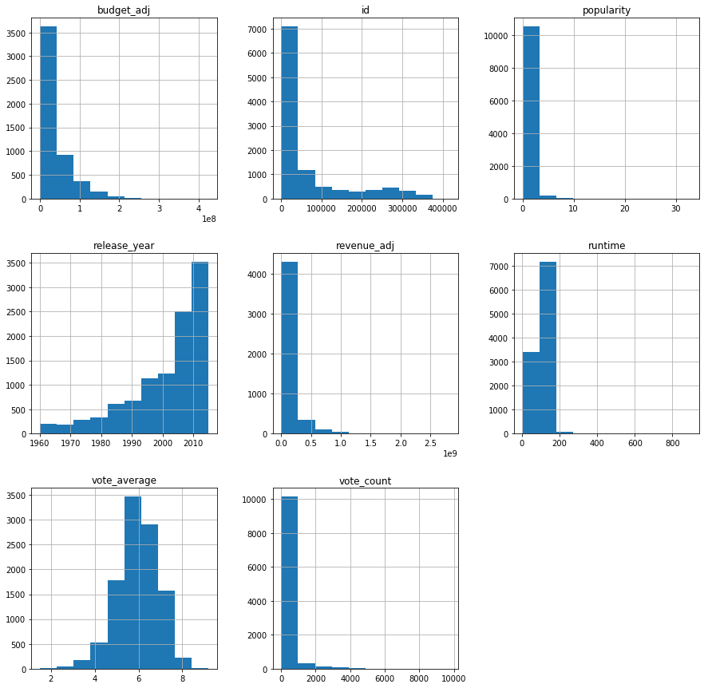

```python
# Histogram
data.hist(figsize = (15, 15));
```

> At the outset, we can see that only the **vote_average column follows a nearly normal distribution with a slight left skew.** The rest of the columns seem to follow some form of a power-law distribution.

```python
# Creating a subset of the main data grouped by year to check for chronological trend
data_subset1 = data.groupby('release_year').mean()
```

```python
# Viewing the subsetted data
data_subset1.head()
```

| release_year | id | popularity | runtime | vote_count | vote_average | budget_adj | revenue_adj |
| --- | --- | --- | --- | --- | --- | --- | --- |
| 1960 | 15715.281250 | 0.458932 | 110.656250 | 77.531250 | 6.325000 | 1.806946e+07 | 1.527310e+08 |
| 1961 | 18657.000000 | 0.422827 | 119.419355 | 77.580645 | 6.374194 | 2.588946e+07 | 2.463622e+08 |
| 1962 | 17001.062500 | 0.454783 | 124.343750 | 74.750000 | 6.343750 | 2.817583e+07 | 1.726663e+08 |
| 1963 | 16556.000000 | 0.502706 | 111.323529 | 82.823529 | 6.329412 | 4.746668e+07 | 1.906224e+08 |
| 1964 | 17379.571429 | 0.412428 | 109.214286 | 74.690476 | 6.211905 | 2.523429e+07 | 2.996491e+08 |

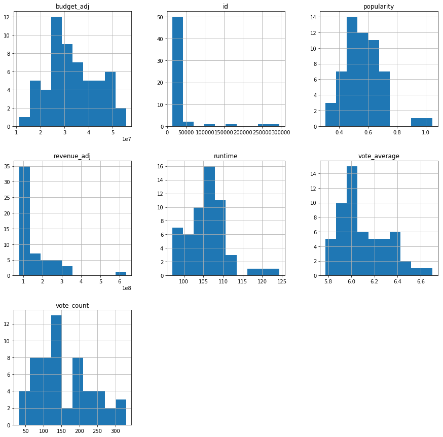

```python
# Histogram of the subsetted data
data_subset1.hist(figsize = (15, 15));
```

> Almost all columns now seem to follow a nearly normal distribution.

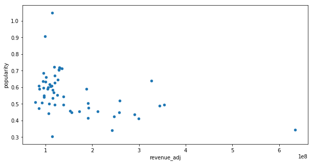

```python
# Scatterplot of revenue_adj and popularity
data_subset1.plot(x = 'revenue_adj', y = 'popularity', kind = 'scatter', figsize = (10, 5));
```

```python
# Correlation between revenue_adj and popularity
data_subset1['revenue_adj'].corr(data_subset1['popularity'])
```

```
-0.42914866339440055
```

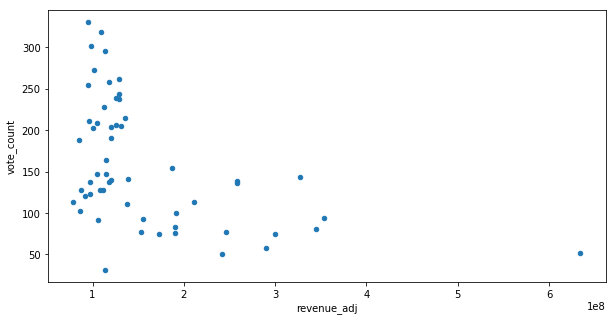

```python
# Scatterplot between revenue_adj and vote count
data_subset1.plot(x = 'revenue_adj', y = 'vote_count', kind = 'scatter', figsize = (10, 5));
```

```python
# Correlation between revenue_adj and vote_count
data_subset1['revenue_adj'].corr(data_subset1['vote_count'])
```

```
-0.47035550774683965
```

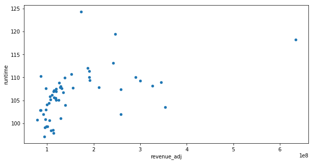

```python
# Scatterplot between revenue_adj and runtime
data_subset1.plot(x = 'revenue_adj', y = 'runtime', kind = 'scatter', figsize = (10, 5));
```

```python
# Correlation between revenue_adj and runtime
data_subset1['revenue_adj'].corr(data_subset1['runtime'])
```

```
0.50858186966032148
```

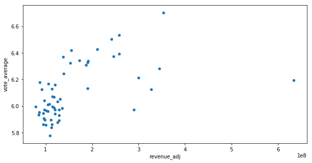

```python
# Scatterplot between revenue_adj and vote average
data_subset1.plot(x = 'revenue_adj', y = 'vote_average', kind = 'scatter', figsize = (10, 5));
```

```python
# Correlation between revenue_adj and vote_average
data_subset1['revenue_adj'].corr(data_subset1['vote_average'])
```

```
0.52872319412254565
```

#### Inferences

> We can draw the following inferences for each pair of variables that we analyzed using scatterplots and correlation coefficients:

> **1. Revenue and Popularity -** Revenue and popularity show a moderate negative correlation with an inverse relationship (evident from the graph) and a correlation coefficient of -0.43.

> **2. Revenue and Vote Count -** Revenue and vote count show a moderate negative correlation with an inverse relationship (evident from the graph) and a correlation coefficient of -0.47.

> **3. Revenue and Runtime -** Revenue and runtime show a moderate positive correlation with a positive relationship (evident from the graph) and a correlation coefficient of +0.51.

> **4. Revenue and Vote Average -** Revenue and vote average show a moderate positive correlation with a positive relationship (evident from the graph) and a correlation coefficient of +0.53.

### Research Question 2 - Does the release date (month) of a movie/tv series affect its popularity, revenue, vote count, and vote average?

> This question explores the relationship between the release month of a movie and its popularity, revenue, vote count and vote average. The idea here is to argue whether a particular month of release may be best suited in order to, say, bag the most revenue or ensure that a movie enjoys high popularity.

#### Data Visualization and Analysis

```python
# Our first order of business here is to extract a month column from the release_date column.

data['month'] = data['release_date'].apply(lambda x: x.month)
data.head()
```

|  | id | popularity | original_title | runtime | release_date | vote_count | vote_average | release_year | budget_adj | revenue_adj | month |
| --- | --- | --- | --- | --- | --- | --- | --- | --- | --- | --- | --- |
| 0 | 135397 | 32.985763 | Jurassic World | 124.0 | 2015-06-09 | 5562 | 6.5 | 2015 | 1.379999e+08 | 1.392446e+09 | 6 |
| 1 | 76341 | 28.419936 | Mad Max: Fury Road | 120.0 | 2015-05-13 | 6185 | 7.1 | 2015 | 1.379999e+08 | 3.481613e+08 | 5 |
| 2 | 262500 | 13.112507 | Insurgent | 119.0 | 2015-03-18 | 2480 | 6.3 | 2015 | 1.012000e+08 | 2.716190e+08 | 3 |
| 3 | 140607 | 11.173104 | Star Wars: The Force Awakens | 136.0 | 2015-12-15 | 5292 | 7.5 | 2015 | 1.839999e+08 | 1.902723e+09 | 12 |
| 4 | 168259 | 9.335014 | Furious 7 | 137.0 | 2015-04-01 | 2947 | 7.3 | 2015 | 1.747999e+08 | 1.385749e+09 | 4 |

```python
# Let us start with month vs revenue
# Group by month and aggregate on the revenue by sum

revenue_by_month = data.groupby('month')['revenue_adj'].sum()
revenue_by_month
```

```
month
1     1.741505e+10
2     2.345234e+10
3     4.069054e+10
4     3.165277e+10
5     6.168336e+10
6     8.071322e+10
7     5.851751e+10
8     3.255990e+10
9     3.095784e+10
10    3.844519e+10
11    5.849807e+10
12    8.349306e+10
Name: revenue_adj, dtype: float64
```

> We notice that the 12th and the 6th months are the highest grossing months in terms of revenue, followed by the 5th and the 7th months. It may not be accurate to make the conclusion about the best months yet since the revenue is also a function of the number of movies released in those months. Therefore, we count the movies before proceeding.

```python
# Finding the count of movies per month
data['month'].value_counts()
```

```
9     1318
10    1138
12     974
8      906
1      892
6      822
3      813
5      807
11     798
4      791
7      790
2      680
Name: month, dtype: int64
```

```python
# Finding the mean no. of movies released per year
data['month'].value_counts().mean()
```

```
894.08333333333337
```

> We can clearly see how the number of movies released can skew the revenue. In this case, the 9th and 10th months have a lot more releases and a really low gross revenue when compared to the 6th and 12th months.

> We now repeat this process for the remaining variables.

```python
# Month vs popularity
# Group by month and aggregate on the popularity by sum

pop_by_month = data.groupby('month')['popularity'].sum()
pop_by_month
```

```
month
1     420.058996
2     406.162833
3     526.582321
4     447.490868
5     606.555554
6     661.517986
7     595.995752
8     534.330657
9     748.363933
10    705.075782
11    613.153629
12    737.457617
Name: popularity, dtype: float64
```

> Here, the clear top two contenders for popularity are the months of September and December. It is interesting to note here that December emerges as a winning candidate yet again and the popularity of September has the potential of being influenced since it is the month with the highest number of movie releases.

```python
# Month vs vote count
# Group by month and aggregate on the vote count by sum

vc_by_month = data.groupby('month')['vote_count'].sum()
vc_by_month
```

```
month
1     108181
2     121923
3     182265
4     151342
5     242690
6     268989
7     238268
8     148274
9     212915
10    215194
11    207518
12    261224
Name: vote_count, dtype: int64
```

> Having accounted for all explored factors, December stands out as one of the best contenders in terms of vote counts.

```python
# Month vs vote average
# Group by month and aggregate on the vote average by sum

va_by_month = data.groupby('month')['vote_average'].sum()
va_by_month
```

```
month
1     5212.6
2     4020.4
3     4809.9
4     4640.7
5     4814.4
6     4937.1
7     4672.6
8     5281.0
9     7991.1
10    6771.2
11    4827.2
12    6019.2
Name: vote_average, dtype: float64
```

> The top two months for vote average are September and October, followed by December.

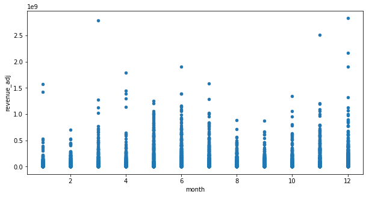

```python
# Plot for Month vs Revenue
data.plot(x = 'month', y = 'revenue_adj', kind = 'scatter', figsize = (10, 5));
```

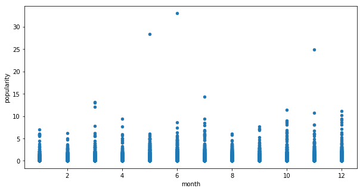

```python
# Plot for Month vs Popularity
data.plot(x = 'month', y = 'popularity', kind = 'scatter', figsize = (10, 5));
```

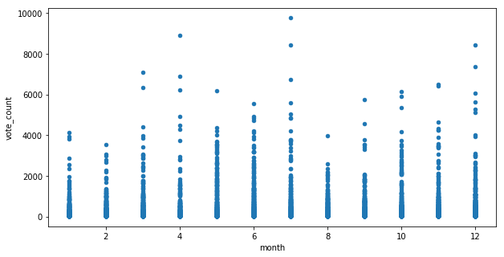

```python
# Plot for Month vs Vote count
data.plot(x = 'month', y = 'vote_count', kind = 'scatter', figsize = (10, 5));
```

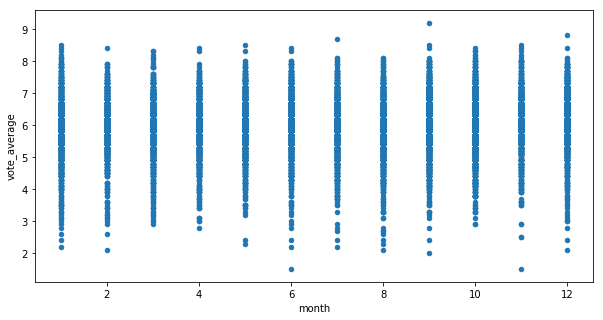

```python
# Plot for Month vs Vote average
data.plot(x = 'month', y = 'vote_average', kind = 'scatter', figsize = (10, 5));
```

> Through the visualizations we are able to graphically affirm our findings. We can also notice the presence of outliers in the graphs.

#### Inferences

> We could infer the following about the 4 pairs of variables chosen for this analysis:

> **1. Month and Revenue -** If you want to maximize your revenue, the months of June and December (December moreso) are likely to be the best months for movie release.

> **3. Month and Vote count -** If you want to maximize your vote count, the months of June and December are likely to be the best months for movie release.

## Conclusions

#### Summary Report

> This analysis of the TMDb dataset has revealed interesting insight for the questions that were posed at the beginning. These questions might be helpful for production houses and movie makers given the kind of information that we have generated from this exploration.

> In summary:

> **Research Question 1 -** Revenue-popularity and revenue-vote count seem to enjoy an inverse relationship. As counterintuitive as it may seem, a higher revenue may not lead to a higher popularity and vice-versa. Additionally, a higher revenue may not yield higher vote counts and vice-versa.

> Revenue-runtime and revenue-vote average seem to enjoy a positive relationship. This implies that the higher the revenue, the higher the runtime for the movies in this data set and vice-versa. Additionally, the higher the revenue the higher the vote average which, funnily enough, seems to contradict the previous findings about revenue-vote count.

> **Note:** The relationship between vote count and vote average have not been separately explored in this project.

#### Limitations

> 1. The analyses may have been biased due to the no. of movies released per month particularly when understanding the best months for movie release.
> 2. The dataset itself suffered from a no. of 0 values which seem to be an entry error. This may have compromised almost half the samples and resulted in poorer insights.
> 3. Other factors such as cast, genres, directors, et al. have not been explored in this project. Perhaps including them would yield better, more conclusive results.
> 4. At the end of the day, this is just EDA and perhaps building a model (e.g. Linear model) would give us a better picture in terms of making predictions on this data.

#### References

> https://stackoverflow.com/questions/25146121/extracting-just-month-and-year-from-pandas-datetime-column-python

> Special thanks to Carly Hochreiter (https://carly-data.com/)

```python
from subprocess import call
call(['python', '-m', 'nbconvert', 'Investigate_a_Dataset.ipynb'])
```